# assignment

Jesslyn Jesslyn

2025-05-17

```r
suppressPackageStartupMessages({
  library(epiwraps)
  library(ggplot2)
  library(AnnotationHub)
  library(ensembldb)
  library(edgeR)
  library(rtracklayer)
  library(BiocParallel)
  library(bsseq)   # Class and tools to analyze bisulfite sequencing data at CpG-level
  library(DMRcate) # Identification of differentially-methylated regions
  library(rGREAT)
})
```

## 1. Plot a heatmap of the methylation levels of the genes in top 20 DMRs located on chr1. You may either do this as we did for promoters during the practical (i.e. using `getMeth()`), or using `signal2Matrix()` and `plotEnrichedHeatmaps()`.

```r
dmrRanges <- readRDS("dmr.rds") #from practical
genes <- readRDS("hg19_chr1_genes.rds") #from practical
# head(dmrRanges)
```

Filter for DMRs in chr1, then filter for the top 20 DMRs

```r
dmr_chr1 <- dmrRanges[seqnames(dmrRanges) == "chr1"]
dmr_chr1 <- dmr_chr1[order(dmr_chr1$HMFDR),]
dmr_top20_chr1 <- head(dmr_chr1,20)
```

Find genes that are in the filtered DMRs

```r
dmr_genes <- genes[overlapsAny(genes, dmr_top20_chr1)]
```

Filters out CpGs with 0 coverage and smooths methylation data

```r
bs <- readRDS("ESC_astrocytes_BSseq.rds")
# remove CpGs that have 0 coverage in some samples:
bs <- bs[rowSums(assay(bs,"Cov")>1)==ncol(bs),]
bs <- BSmooth(bs, BPPARAM=MulticoreParam(4, progress=FALSE))
```

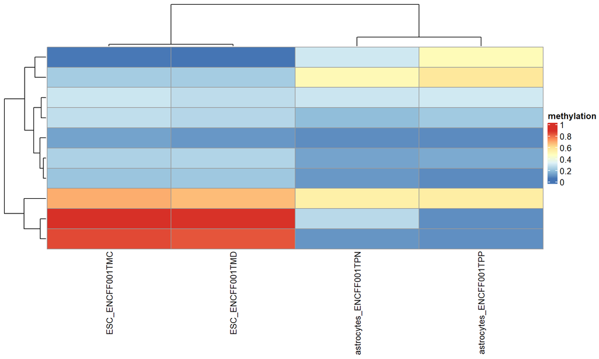

```r
# Visualize methylation level of genes in top 20 DMRs in chr1
dmrs <- bsseq::getMeth(bs, regions=dmr_genes, what="perRegion")
colnames(dmrs) <- colnames(bs)
pheatmap(dmrs, name="methylation")
```

## 2. Run an enrichment analysis (rGREAT) of the significant DMRs from the practical against the entire genome. Describe what your enrichment analysis is testing exactly & describe the results

```r
# head(dmrRanges)
res <- great(dmrRanges, gene_sets="GO:BP", tss_source="hg19", cores=2)
```

```
## * TSS source: TxDb.
```

```
## * check whether TxDb package 'TxDb.Hsapiens.UCSC.hg19.knownGene' is installed.
```

```
## * gene ID type in the extended TSS is 'Entrez Gene ID'.
```

[output not shown]

```
## * 18561/23033 protein-coding genes left.
```

```
## * update seqinfo to the selected chromosomes.
```

```
## * TSS extension mode is 'basalPlusExt'.
```

[output not shown]

```
## * calculate distances to neighbour regions.
```

[output not shown]

```
## * use GO:BP ontology with 15413 gene sets (source: org.Hs.eg.db).
```

```
## * check gene ID type in `gene_sets` and in `extended_tss`.
```

```
## * use whole genome as background.
```

```
## * remove excluded regions from background.
```

```
## * overlap `gr` to background regions (based on midpoint).
```

```
## * in total 2797 `gr`.
```

```
## * overlap extended TSS to background regions.
```

```
## * check which genes are in the gene sets.
```

```
## * only take gene sets with size >= 5.
```

```
## * in total 9094 gene sets.
```

```
## * overlap `gr` to every extended TSS.
```

```
## * perform binomial test for each biological term.
```

```r
bp <- getEnrichmentTables(res)
# head(bp)
```

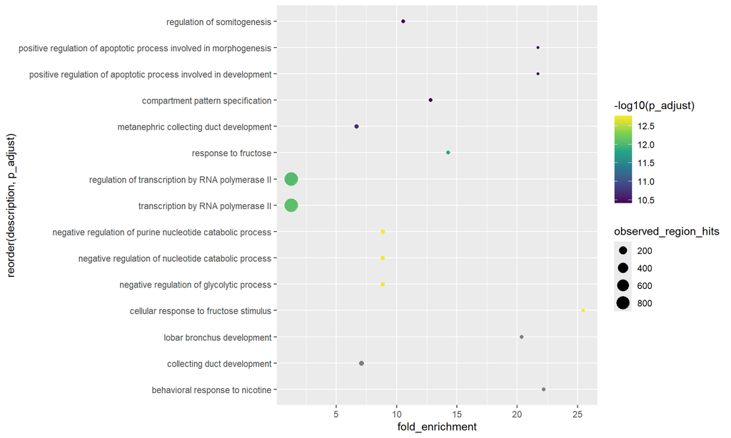

```r
ggplot(head(bp,15), aes(fold_enrichment, reorder(description, p_adjust),
                        size=observed_region_hits, color=-log10(p_adjust))) +
  geom_point() + scale_color_viridis_c()
```

The enrichment analysis describes whether the significant DMRs (differentially methylated regions between ESCs and astrocytes) are associated with specific biological processes more frequently than expected by chance, as compared to the rest of the genome.

The results show that the DMRs identified between ESCs and astrocytes are significantly enriched in the following biological processes:

1. Developmental (eg. regulation of somitogenesis, lobar bronchus development)
2. Transcription (eg. regulation of transcription by RNA polymerase II, transcription by RNA polymerase II)
3. Metabolic (eg. cellular response to fructose stimulus, negative regulation of nucleotide catabolic process)

This suggests that significant changes in DNA methylation levels during astrocyte differentiation may be involved in development and metabolic processes.